# Reproducable data Peer Project 1

garyf

Saturday, February 14, 2015

This is the peer assessed project one. I have a long history with relational databases. (My favorite SAS PROC is Proc SQL) I am using the R equivilent R library. sqldf

I also discovered the iterator library, I think this will be most helpful …

I am doing both the SQL way and the R way. I am seeing some differences and I am not sure if the SQL way is the best way to query a data.frame. Please watch for this as there might be 2 analysis per question / part…

# Initial analysis, daily histogram.

```r
require(sqldf)
require(iterators)
fitbit <- read.csv("data1/activity.csv")
groupSum <- sqldf("select date, sum(steps) as sum_steps from fitbit where steps != 'NA' group by date")
```

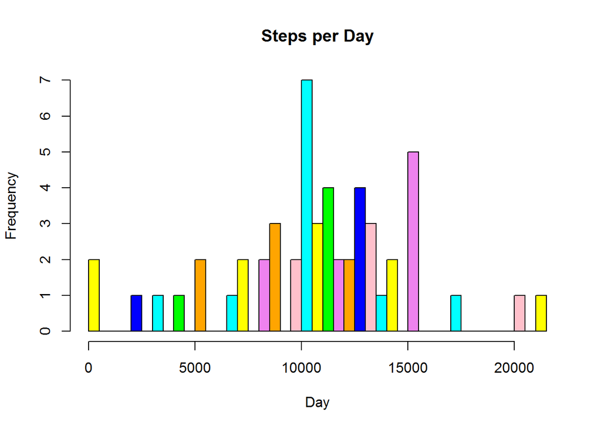

```r
minAverage <- sqldf("select interval, avg(steps) as avg_steps from fitbit where steps != 'NA' group by interval")
 colors = c( "yellow", "green", "violet", "orange",  "blue", "pink", "cyan")

 hist( groupSum$sum_steps ,    # apply the hist function
  breaks=53,  # number of observations over 2 months
   right=FALSE,    # intervals closed on the left
   col=colors,     # set the color palette
   main="Steps per Day", # the main title
   xlab="Day")       # x-axis label
```

The number of steps by time of day; grouped by 5 minute groups

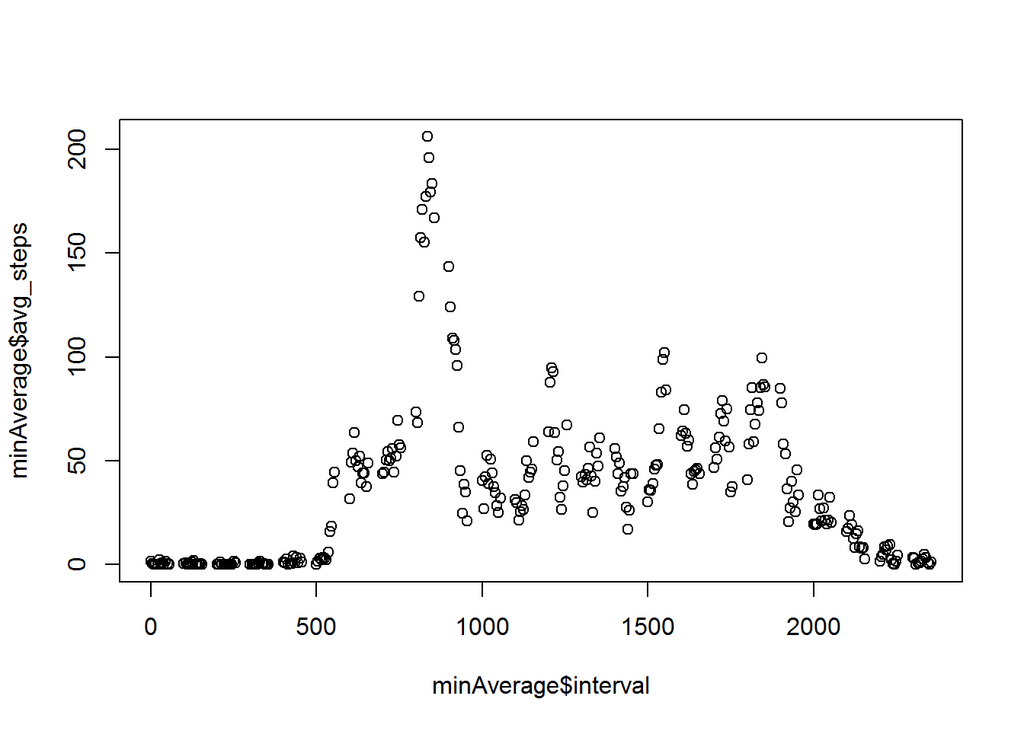

```r
 plot(x=minAverage$interval, y=minAverage$avg_steps)
```